# Module 155

#### Hemi-module gene counts:

121 probesets in hemi-module A.  
54 probesets in hemi-module B.  
Note: While the mapping of probesets to genes is usually one-to-one, some genes are targeted by multiple probesets, some probesets target multiple genes, and some probesets do not target any genes (i.e., the region of the genome they match is no longer considered genic).

#### Contrast SVE:

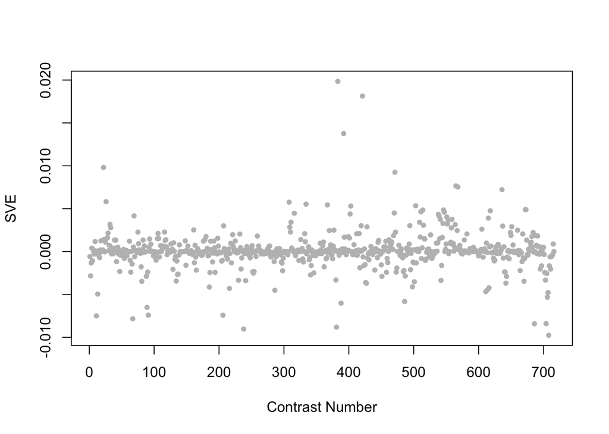

Positive SVE Contrasts:

|  | Contrast.Num | SVE | GEO.GSE | Cond.1 | Cond.2 | Mutation |
| --- | --- | --- | --- | --- | --- | --- |
| GSE34113.s1t1.vs.s0t1 | 383 | 0.02 | GSE34113 | tdp-1(ok803) | wild-type 1 | tdp-1 |
| GSE28494.s1t2.vs.s0t2 | 421 | 0.02 | GSE28494 | lin-54(n3423) dissected germline 1 | wild-type N2 dissected germline 1 | lin-54 |
| GSE32339.s1t2.vs.s0t2 | 392 | 0.01 | GSE32339 | Adult Mutant, biological rep1 | Adult Wild-type, biological rep1 | nep-1 |
| GSE9665.s1t2.vs.s0t2 | 22 | 0.01 | GSE9665 | mex-3 elt-1 186 A | mex-3 186 A | elt-1 |
| GSE23528A.s1t2.vs.s0t2 | 471 | 0.01 | GSE23528 | Adult at T6 in LD, time-series experiment 3 | Adult at T6, non-entrained control time-series experiment 4 |  |

Negative SVE Contrasts:

|  | Contrast.Num | SVE | GEO.GSE | Cond.1 | Cond.2 | Mutation |
| --- | --- | --- | --- | --- | --- | --- |
| GSE11055.s1t8.vs.s1t1 | 708 | -0.01 | GSE11055 | L2 larvae 24 hr after hatching in the presence of food | embryo 2 hr before hatching |  |
| GSE42592C.s1t2.vs.s0t2 | 238 | -0.01 | GSE42592 | mercury_low_expose-4h_rep1 | mercury_control_expose-4h_rep1 |  |
| GSE34471.s0t2.vs.s0t1 | 381 | -0.01 | GSE34471 | 20uM-Con-1 | 4uM-Con-1 |  |
| GSE12298C.s1t1.vs.s0t1 | 686 | -0.01 | GSE12298 | mefloquine_low_dose-rep1 | mefloquine_control-rep1 |  |
| GSE11055.s1t6.vs.s1t1 | 704 | -0.01 | GSE11055 | L1 larvae 12 hr after hatching in the presence of food | embryo 2 hr before hatching |  |

$~$

#### Contrast SVE, Up-Regulated Genes Only:

Calculating SVE for up-regulated and down-regulated genes separately may be more informative in many cases than projecting the up- and down- gene sets together. This is due to the fact that the weight distribution of many modules is highly skewed, indicating that only one of the hemi-modules may be biologically meaningful (i.e., a set of genes are strongly correlated by only a few genes (or none) are strongly anti-correlated to that set.)

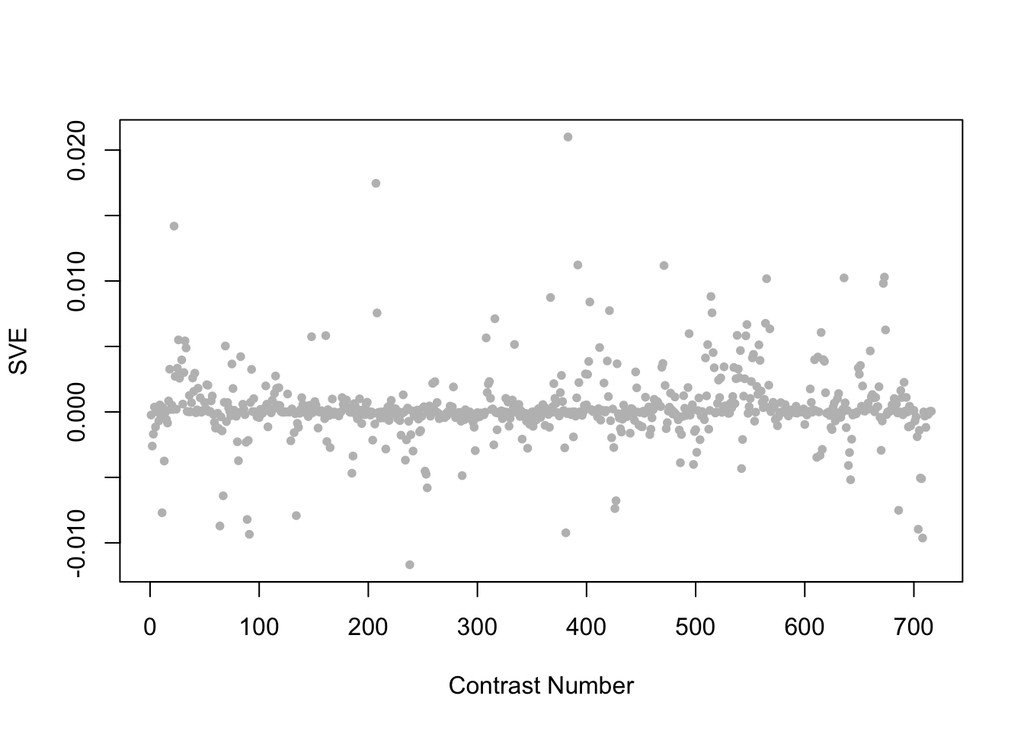

Positive SVE Contrasts:

|  | Contrast.Num | SVE | GEO.GSE | Cond.1 | Cond.2 | Mutation |
| --- | --- | --- | --- | --- | --- | --- |
| GSE34113.s1t1.vs.s0t1 | 383 | 0.02 | GSE34113 | tdp-1(ok803) | wild-type 1 | tdp-1 |
| GSE42703.s1t2.vs.s1t1 | 207 | 0.02 | GSE42703 | kgb-1 incubated with H2O, biological rep1 | kgb-1 incubated with 1mM copper sulfate, biological rep1 |  |
| GSE9665.s1t2.vs.s0t2 | 22 | 0.01 | GSE9665 | mex-3 elt-1 186 A | mex-3 186 A | elt-1 |
| GSE32339.s1t2.vs.s0t2 | 392 | 0.01 | GSE32339 | Adult Mutant, biological rep1 | Adult Wild-type, biological rep1 | nep-1 |
| GSE23528A.s1t2.vs.s0t2 | 471 | 0.01 | GSE23528 | Adult at T6 in LD, time-series experiment 3 | Adult at T6, non-entrained control time-series experiment 4 |  |

Negative SVE Contrasts:

|  | Contrast.Num | SVE | GEO.GSE | Cond.1 | Cond.2 | Mutation |
| --- | --- | --- | --- | --- | --- | --- |
| GSE42592C.s1t2.vs.s0t2 | 238 | -0.01 | GSE42592 | mercury_low_expose-4h_rep1 | mercury_control_expose-4h_rep1 |  |
| GSE11055.s1t8.vs.s1t1 | 708 | -0.01 | GSE11055 | L2 larvae 24 hr after hatching in the presence of food | embryo 2 hr before hatching |  |
| GSE6547.s1t3.vs.s1t1 | 91 | -0.01 | GSE6547 | lin-35(n745) worms at L4 stage, first replicate | lin-35(n745) worms at embryonic stage, first replicate |  |
| GSE34471.s0t2.vs.s0t1 | 381 | -0.01 | GSE34471 | 20uM-Con-1 | 4uM-Con-1 |  |
| GSE11055.s1t6.vs.s1t1 | 704 | -0.01 | GSE11055 | L1 larvae 12 hr after hatching in the presence of food | embryo 2 hr before hatching |  |

$~$

#### Contrast SVE, Down-Regulated Genes Only:

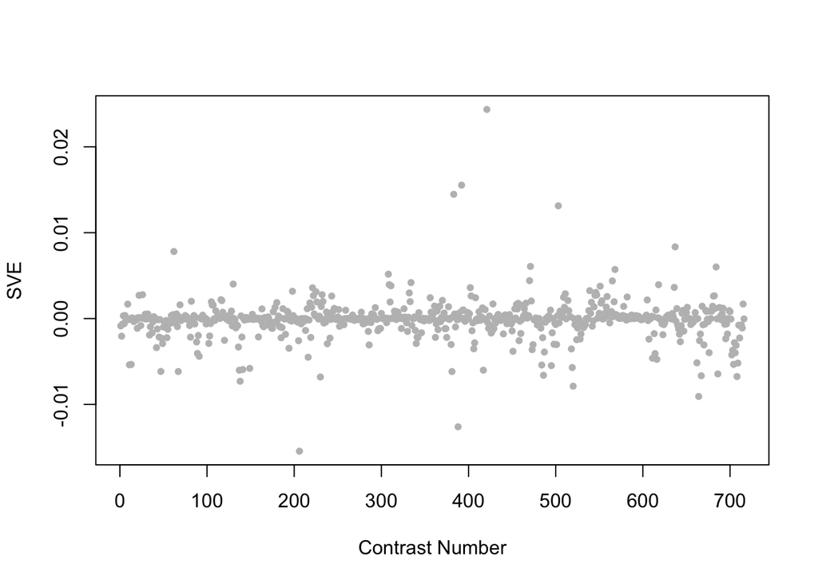

Positive SVE Contrasts:

|  | Contrast.Num | SVE | GEO.GSE | Cond.1 | Cond.2 | Mutation |
| --- | --- | --- | --- | --- | --- | --- |
| GSE28494.s1t2.vs.s0t2 | 421 | 0.02 | GSE28494 | lin-54(n3423) dissected germline 1 | wild-type N2 dissected germline 1 | lin-54 |
| GSE32339.s1t2.vs.s0t2 | 392 | 0.02 | GSE32339 | Adult Mutant, biological rep1 | Adult Wild-type, biological rep1 | nep-1 |
| GSE34113.s1t1.vs.s0t1 | 383 | 0.01 | GSE34113 | tdp-1(ok803) | wild-type 1 | tdp-1 |
| GSE22660.s1t2.vs.s0t2 | 503 | 0.01 | GSE22660 | 1ug/ml ivermectin exposure, biological rep 1 | 1ug/ml DMSO control, biological rep 1 |  |
| GSE18132.s1t2.vs.s0t2 | 637 | 0.01 | GSE18132 | Ogt Fed L4, biological replicate 1 | WT Fed L4, biological rep1 | ogt-1 |

Negative SVE Contrasts:

|  | Contrast.Num | SVE | GEO.GSE | Cond.1 | Cond.2 | Mutation |
| --- | --- | --- | --- | --- | --- | --- |
| GSE42703.s2t2.vs.s1t2 | 206 | -0.02 | GSE42703 | WT incubated with H2O, biological rep1 | kgb-1 incubated with H2O, biological rep1 | kgb-1 |
| GSE32949.s1t1.vs.s0t1 | 388 | -0.01 | GSE32949 | C. elegans exposed to space condition, technical rep1 | C. elegans ground control, technical rep1 |  |
| GSE15159.s2t2.vs.s0t2 | 664 | -0.01 | GSE15159 | xpa-1_UV_2007_rep1 | N2_UV_2007_rep1 | xpa-1 |
| GSE2180.s4t7.vs.s3t7 | 520 | -0.01 | GSE2180 | pp101-1 | p101-2 | pal-1(RNAi) |
| GSE51691.s4t1.vs.s1t1 | 138 | -0.01 | GSE51691 | day8 hermaphrodite utx-1 RNAi +males rep 1 | day8 hermaphrodite -males rep 1 |  |

$~$

$~$

#### GO Term Enrichment:

This analysis tests each hemi-module for enrichment of specific GO terms. Only gene-level annotations (e.g., as would be found on the gene’s page in Wormbase) are tested - the hierarchical structure of the GO ontology is not taken into account.

*Note: At least the top two most enriched terms from each GO domain (BP/MF/CC) are shown, even when not statistically significant.*

##### Enriched GO terms: Hemi-module A

| ID | GO.Term | GO Domain | Raw p-value | Adj p-value |
| --- | --- | --- | --- | --- |
| [GO_0009653](http://amigo.geneontology.org/amigo/term/GO:0009653) | anatomical structure morphogenesis | BP | 1.98e-04 | 7.20e-01 |
| [GO_0006777](http://amigo.geneontology.org/amigo/term/GO:0006777) | Mo-molybdopterin cofactor biosynthetic process | BP | 1.44e-03 | 9.96e-01 |
| [GO_0000981](http://amigo.geneontology.org/amigo/term/GO:0000981) | DNA-binding transcription factor activity, RNA polymerase II-specific | MF | 1.58e-04 | 3.22e-01 |
| [GO_0015929](http://amigo.geneontology.org/amigo/term/GO:0015929) | hexosaminidase activity | MF | 7.78e-04 | 7.95e-01 |
| [GO_1902636](http://amigo.geneontology.org/amigo/term/GO:1902636) | kinociliary basal body | CC | 7.31e-03 | 9.97e-01 |
| [GO_0005851](http://amigo.geneontology.org/amigo/term/GO:0005851) | eukaryotic translation initiation factor 2B complex | CC | 2.18e-02 | 9.97e-01 |

##### Enriched GO terms: Hemi-module B

| ID | GO.Term | GO Domain | Raw p-value | Adj p-value |
| --- | --- | --- | --- | --- |
| [GO_0009408](http://amigo.geneontology.org/amigo/term/GO:0009408) | response to heat | BP | 3.25e-04 | 1.00e+00 |
| [GO_0006986](http://amigo.geneontology.org/amigo/term/GO:0006986) | response to unfolded protein | BP | 9.42e-04 | 1.00e+00 |
| [GO_0046872](http://amigo.geneontology.org/amigo/term/GO:0046872) | metal ion binding | MF | 1.38e-03 | 8.97e-01 |
| [GO_0001164](http://amigo.geneontology.org/amigo/term/GO:0001164) | RNA polymerase I CORE element sequence-specific DNA binding | MF | 3.08e-03 | 8.97e-01 |
| [GO_0005623](http://amigo.geneontology.org/amigo/term/GO:0005623) | cell | CC | 4.18e-04 | 3.88e-01 |
| [GO_0005668](http://amigo.geneontology.org/amigo/term/GO:0005668) | RNA polymerase transcription factor SL1 complex | CC | 3.08e-03 | 9.51e-01 |

$~$

$~$

#### Tissue Enrichment:

This analysis tests each hemi-module for enrichment of genes associated with anatomy terms. Negative enrichment scores indicate fewer hemi-module genes than expected by random chance were associated with the anatomy term in question.

##### Enriched tissues: Hemi-module A

| ID | Anatomy.Term | Definition | Raw p-value | Adj p-value |
| --- | --- | --- | --- | --- |
| [WBbt_0006288](https://wormbase.org/species/all/anatomy_term/WBbt:0006288) | ABalpapap | embryonic cell | 5.19e-05 | 2.51e-02 |
| [WBbt_0006386](https://wormbase.org/species/all/anatomy_term/WBbt:0006386) | ABalpapaa | embryonic cell | 6.06e-05 | 2.51e-02 |
| [WBbt_0006081](https://wormbase.org/species/all/anatomy_term/WBbt:0006081) | Dappa | embryonic cell | 6.61e-05 | 2.51e-02 |
| [WBbt_0006482](https://wormbase.org/species/all/anatomy_term/WBbt:0006482) | Dpppa | embryonic cell | 6.61e-05 | 2.51e-02 |
| [WBbt_0006099](https://wormbase.org/species/all/anatomy_term/WBbt:0006099) | ABplpaaaa | embryonic cell | 8.10e-05 | 2.51e-02 |
| [WBbt_0006383](https://wormbase.org/species/all/anatomy_term/WBbt:0006383) | MSppap | embryonic cell | 8.10e-05 | 2.51e-02 |
| [WBbt_0006631](https://wormbase.org/species/all/anatomy_term/WBbt:0006631) | ABpraaaaa | embryonic cell | 8.10e-05 | 2.51e-02 |
| [WBbt_0006313](https://wormbase.org/species/all/anatomy_term/WBbt:0006313) | ABplpaaap | embryonic cell | 9.29e-05 | 2.51e-02 |
| [WBbt_0006421](https://wormbase.org/species/all/anatomy_term/WBbt:0006421) | ABplpaapp | embryonic cell | 9.29e-05 | 2.51e-02 |
| [WBbt_0006409](https://wormbase.org/species/all/anatomy_term/WBbt:0006409) | MSpppp | embryonic cell | 1.20e-04 | 2.55e-02 |
| [WBbt_0006490](https://wormbase.org/species/all/anatomy_term/WBbt:0006490) | ABprpaaap | embryonic cell | 1.20e-04 | 2.55e-02 |
| [WBbt_0006047](https://wormbase.org/species/all/anatomy_term/WBbt:0006047) | ABprpaapa | embryonic cell | 1.36e-04 | 2.55e-02 |
| [WBbt_0006115](https://wormbase.org/species/all/anatomy_term/WBbt:0006115) | ABplpaapa | embryonic cell | 1.36e-04 | 2.55e-02 |
| [WBbt_0006531](https://wormbase.org/species/all/anatomy_term/WBbt:0006531) | MSppaa | embryonic cell | 1.54e-04 | 2.67e-02 |
| [WBbt_0006520](https://wormbase.org/species/all/anatomy_term/WBbt:0006520) | Dappp | embryonic cell | 1.97e-04 | 3.20e-02 |
| [WBbt_0006427](https://wormbase.org/species/all/anatomy_term/WBbt:0006427) | ABalaaaa | embryonic cell | 2.39e-04 | 3.63e-02 |
| [WBbt_0005874](https://wormbase.org/species/all/anatomy_term/WBbt:0005874) | Daaap | Embryonic cell of pedigree Daaap. | 3.92e-04 | 4.34e-02 |
| [WBbt_0005989](https://wormbase.org/species/all/anatomy_term/WBbt:0005989) | Dppap | Embryonic cell of pedigree Dppap. | 3.92e-04 | 4.34e-02 |
| [WBbt_0006146](https://wormbase.org/species/all/anatomy_term/WBbt:0006146) | Daaaa | Embryonic cell of pedigree Daaaa. | 3.92e-04 | 4.34e-02 |
| [WBbt_0006329](https://wormbase.org/species/all/anatomy_term/WBbt:0006329) | Dpppp | embryonic cell | 3.92e-04 | 4.34e-02 |
| [WBbt_0006481](https://wormbase.org/species/all/anatomy_term/WBbt:0006481) | Dpaaa | Embryonic cell of pedigree Dpaaa. | 3.92e-04 | 4.34e-02 |
| [WBbt_0006634](https://wormbase.org/species/all/anatomy_term/WBbt:0006634) | Dpaap | Embryonic cell of pedigree Dpaap. | 3.92e-04 | 4.34e-02 |
| [WBbt_0006128](https://wormbase.org/species/all/anatomy_term/WBbt:0006128) | Dpapa | Embryonic cell of pedigree Dpapa. | 6.51e-04 | 5.65e-02 |
| [WBbt_0006344](https://wormbase.org/species/all/anatomy_term/WBbt:0006344) | Dapaa | Embryonic cell of pedigree Dapaa. | 6.51e-04 | 5.65e-02 |
| [WBbt_0006366](https://wormbase.org/species/all/anatomy_term/WBbt:0006366) | Dpapp | Embryonic cell of pedigreeDpapp . | 6.51e-04 | 5.65e-02 |
| [WBbt_0006381](https://wormbase.org/species/all/anatomy_term/WBbt:0006381) | Daapa | Embryonic cell of pedigree Daapa. | 6.51e-04 | 5.65e-02 |
| [WBbt_0006435](https://wormbase.org/species/all/anatomy_term/WBbt:0006435) | Daapp | Embryonic cell of pedigree Daapp. | 6.51e-04 | 5.65e-02 |
| [WBbt_0006704](https://wormbase.org/species/all/anatomy_term/WBbt:0006704) | Dppaa | Embryonic cell of pedigree Dppaa. | 6.51e-04 | 5.65e-02 |
| [WBbt_0006064](https://wormbase.org/species/all/anatomy_term/WBbt:0006064) | ABaraappp | embryonic cell | 8.18e-04 | 6.86e-02 |
| [WBbt_0006654](https://wormbase.org/species/all/anatomy_term/WBbt:0006654) | ABaraapaa | embryonic cell | 9.30e-04 | 7.38e-02 |
| [WBbt_0006257](https://wormbase.org/species/all/anatomy_term/WBbt:0006257) | ABalpapaaa | embryonic cell | 9.71e-04 | 7.38e-02 |
| [WBbt_0006535](https://wormbase.org/species/all/anatomy_term/WBbt:0006535) | Dapap | Embryonic cell of pedigree Dapap. | 9.71e-04 | 7.38e-02 |
| [WBbt_0005978](https://wormbase.org/species/all/anatomy_term/WBbt:0005978) | ABaraappa | embryonic cell | 1.18e-03 | 8.70e-02 |
| [WBbt_0005846](https://wormbase.org/species/all/anatomy_term/WBbt:0005846) | ABalppapa | embryonic cell | 1.32e-03 | 9.40e-02 |
| [WBbt_0005047](https://wormbase.org/species/all/anatomy_term/WBbt:0005047) | RIR | Neuron class of one ring interneuron. | 1.35e-03 | 9.40e-02 |

##### Enriched tissues: Hemi-module B

No significant annotations.

$~$

$~$

#### HOMER promoter motif enrichment:

This analysis tests each hemi-module for enrichment of 108 known *C. elegans* transcription factor binding site motifs (see [108 CE motifs](https://katiepod.github.io//all.worm.motifs.html)) using the HOMER (Hypergeometric Optimization of Motif EnRichment) software (see [PMID:20513432](https://pubmed.ncbi.nlm.nih.gov/20513432)). HOMER was run using default parameters on sequences 1 kb upstream of the transcription start site.

##### Motif enrichment: Hemi-module A

Total target sequences = 111  
Total background sequences = 40972  
* - possible false positive

Rank

Motif

P-value

log P-pvalue

% of Targets

% of Background

STD(Bg STD)

Best Match/Details

Motif File

1

[figure not shown]

1e-12

-2.863e+01

33.33%

8.70%

258.7bp (301.4bp)

ces-2/MA0922.1/Jaspar(0.694)  
[More Information](https://katiepod.github.io/HomerResults/m155_a_hemi_genes.txt.out.1kb/homerResults/motif1.info.html) | [Similar Motifs Found](https://katiepod.github.io/HomerResults/m155_a_hemi_genes.txt.out.1kb/homerResults/motif1.similar.html)

[motif file (matrix)](https://katiepod.github.io/HomerResults/m155_a_hemi_genes.txt.out.1kb/homerResults/motif1.motif)

2 *

[figure not shown]

1e-10

-2.354e+01

4.50%

0.02%

328.6bp (225.6bp)

POL012.1_TATA-Box/Jaspar(0.492)  
[More Information](https://katiepod.github.io/HomerResults/m155_a_hemi_genes.txt.out.1kb/homerResults/motif2.info.html) | [Similar Motifs Found](https://katiepod.github.io/HomerResults/m155_a_hemi_genes.txt.out.1kb/homerResults/motif2.similar.html)

[motif file (matrix)](https://katiepod.github.io/HomerResults/m155_a_hemi_genes.txt.out.1kb/homerResults/motif2.motif)

3 *

[figure not shown]

1e-9

-2.257e+01

6.31%

0.12%

221.0bp (337.6bp)

eor-1/MA0543.1/Jaspar(0.626)  
[More Information](https://katiepod.github.io/HomerResults/m155_a_hemi_genes.txt.out.1kb/homerResults/motif3.info.html) | [Similar Motifs Found](https://katiepod.github.io/HomerResults/m155_a_hemi_genes.txt.out.1kb/homerResults/motif3.similar.html)

[motif file (matrix)](https://katiepod.github.io/HomerResults/m155_a_hemi_genes.txt.out.1kb/homerResults/motif3.motif)

4 *

[figure not shown]

1e-9

-2.244e+01

8.11%

0.32%

356.2bp (305.4bp)

lim-4/MA0923.1/Jaspar(0.537)  
[More Information](https://katiepod.github.io/HomerResults/m155_a_hemi_genes.txt.out.1kb/homerResults/motif4.info.html) | [Similar Motifs Found](https://katiepod.github.io/HomerResults/m155_a_hemi_genes.txt.out.1kb/homerResults/motif4.similar.html)

[motif file (matrix)](https://katiepod.github.io/HomerResults/m155_a_hemi_genes.txt.out.1kb/homerResults/motif4.motif)

5 *

[figure not shown]

1e-9

-2.225e+01

10.81%

0.82%

215.9bp (314.3bp)

PL0002.1_hlh-2::hlh-3/Jaspar(0.614)  
[More Information](https://katiepod.github.io/HomerResults/m155_a_hemi_genes.txt.out.1kb/homerResults/motif5.info.html) | [Similar Motifs Found](https://katiepod.github.io/HomerResults/m155_a_hemi_genes.txt.out.1kb/homerResults/motif5.similar.html)

[motif file (matrix)](https://katiepod.github.io/HomerResults/m155_a_hemi_genes.txt.out.1kb/homerResults/motif5.motif)

6 *

[figure not shown]

1e-9

-2.200e+01

8.11%

0.34%

301.0bp (300.0bp)

MF0003.1_REL_class/Jaspar(0.556)  
[More Information](https://katiepod.github.io/HomerResults/m155_a_hemi_genes.txt.out.1kb/homerResults/motif6.info.html) | [Similar Motifs Found](https://katiepod.github.io/HomerResults/m155_a_hemi_genes.txt.out.1kb/homerResults/motif6.similar.html)

[motif file (matrix)](https://katiepod.github.io/HomerResults/m155_a_hemi_genes.txt.out.1kb/homerResults/motif6.motif)

7 *

[figure not shown]

1e-9

-2.189e+01

13.51%

1.56%

278.1bp (306.5bp)

elt-3/MA0542.1/Jaspar(0.521)  
[More Information](https://katiepod.github.io/HomerResults/m155_a_hemi_genes.txt.out.1kb/homerResults/motif7.info.html) | [Similar Motifs Found](https://katiepod.github.io/HomerResults/m155_a_hemi_genes.txt.out.1kb/homerResults/motif7.similar.html)

[motif file (matrix)](https://katiepod.github.io/HomerResults/m155_a_hemi_genes.txt.out.1kb/homerResults/motif7.motif)

8 *

[figure not shown]

1e-9

-2.133e+01

11.71%

1.12%

292.4bp (317.1bp)

eor-1/MA0543.1/Jaspar(0.544)  
[More Information](https://katiepod.github.io/HomerResults/m155_a_hemi_genes.txt.out.1kb/homerResults/motif8.info.html) | [Similar Motifs Found](https://katiepod.github.io/HomerResults/m155_a_hemi_genes.txt.out.1kb/homerResults/motif8.similar.html)

[motif file (matrix)](https://katiepod.github.io/HomerResults/m155_a_hemi_genes.txt.out.1kb/homerResults/motif8.motif)

9 *

[figure not shown]

1e-9

-2.104e+01

17.12%

2.93%

270.1bp (301.4bp)

pha-4/MA0546.1/Jaspar(0.632)  
[More Information](https://katiepod.github.io/HomerResults/m155_a_hemi_genes.txt.out.1kb/homerResults/motif9.info.html) | [Similar Motifs Found](https://katiepod.github.io/HomerResults/m155_a_hemi_genes.txt.out.1kb/homerResults/motif9.similar.html)

[motif file (matrix)](https://katiepod.github.io/HomerResults/m155_a_hemi_genes.txt.out.1kb/homerResults/motif9.motif)

10 *

[figure not shown]

1e-9

-2.103e+01

6.31%

0.15%

205.4bp (233.8bp)

ceh-48/MA0921.1/Jaspar(0.586)  
[More Information](https://katiepod.github.io/HomerResults/m155_a_hemi_genes.txt.out.1kb/homerResults/motif10.info.html) | [Similar Motifs Found](https://katiepod.github.io/HomerResults/m155_a_hemi_genes.txt.out.1kb/homerResults/motif10.similar.html)

[motif file (matrix)](https://katiepod.github.io/HomerResults/m155_a_hemi_genes.txt.out.1kb/homerResults/motif10.motif)

11 *

[figure not shown]

1e-8

-2.054e+01

9.91%

0.75%

330.4bp (299.2bp)

fkh-9/MA1440.1/Jaspar(0.612)  
[More Information](https://katiepod.github.io/HomerResults/m155_a_hemi_genes.txt.out.1kb/homerResults/motif11.info.html) | [Similar Motifs Found](https://katiepod.github.io/HomerResults/m155_a_hemi_genes.txt.out.1kb/homerResults/motif11.similar.html)

[motif file (matrix)](https://katiepod.github.io/HomerResults/m155_a_hemi_genes.txt.out.1kb/homerResults/motif11.motif)

12 *

[figure not shown]

1e-8

-1.998e+01

12.61%

1.52%

284.8bp (308.2bp)

SD0003.1_at_AC_acceptor/Jaspar(0.598)  
[More Information](https://katiepod.github.io/HomerResults/m155_a_hemi_genes.txt.out.1kb/homerResults/motif12.info.html) | [Similar Motifs Found](https://katiepod.github.io/HomerResults/m155_a_hemi_genes.txt.out.1kb/homerResults/motif12.similar.html)

[motif file (matrix)](https://katiepod.github.io/HomerResults/m155_a_hemi_genes.txt.out.1kb/homerResults/motif12.motif)

13 *

[figure not shown]

1e-8

-1.959e+01

8.11%

0.45%

248.0bp (320.4bp)

blmp-1/MA0537.1/Jaspar(0.591)  
[More Information](https://katiepod.github.io/HomerResults/m155_a_hemi_genes.txt.out.1kb/homerResults/motif13.info.html) | [Similar Motifs Found](https://katiepod.github.io/HomerResults/m155_a_hemi_genes.txt.out.1kb/homerResults/motif13.similar.html)

[motif file (matrix)](https://katiepod.github.io/HomerResults/m155_a_hemi_genes.txt.out.1kb/homerResults/motif13.motif)

14 *

[figure not shown]

1e-8

-1.931e+01

68.47%

40.86%

274.1bp (301.8bp)

mab-5/MA1442.1/Jaspar(0.708)  
[More Information](https://katiepod.github.io/HomerResults/m155_a_hemi_genes.txt.out.1kb/homerResults/motif14.info.html) | [Similar Motifs Found](https://katiepod.github.io/HomerResults/m155_a_hemi_genes.txt.out.1kb/homerResults/motif14.similar.html)

[motif file (matrix)](https://katiepod.github.io/HomerResults/m155_a_hemi_genes.txt.out.1kb/homerResults/motif14.motif)

15 *

[figure not shown]

1e-8

-1.919e+01

8.11%

0.47%

190.5bp (313.4bp)

che-1/MA0260.1/Jaspar(0.531)  
[More Information](https://katiepod.github.io/HomerResults/m155_a_hemi_genes.txt.out.1kb/homerResults/motif15.info.html) | [Similar Motifs Found](https://katiepod.github.io/HomerResults/m155_a_hemi_genes.txt.out.1kb/homerResults/motif15.similar.html)

[motif file (matrix)](https://katiepod.github.io/HomerResults/m155_a_hemi_genes.txt.out.1kb/homerResults/motif15.motif)

16 *

[figure not shown]

1e-8

-1.902e+01

7.21%

0.33%

302.2bp (290.9bp)

POL003.1_GC-box/Jaspar(0.708)  
[More Information](https://katiepod.github.io/HomerResults/m155_a_hemi_genes.txt.out.1kb/homerResults/motif16.info.html) | [Similar Motifs Found](https://katiepod.github.io/HomerResults/m155_a_hemi_genes.txt.out.1kb/homerResults/motif16.similar.html)

[motif file (matrix)](https://katiepod.github.io/HomerResults/m155_a_hemi_genes.txt.out.1kb/homerResults/motif16.motif)

17 *

[figure not shown]

1e-7

-1.751e+01

6.31%

0.26%

274.4bp (321.7bp)

POL013.1_MED-1/Jaspar(0.562)  
[More Information](https://katiepod.github.io/HomerResults/m155_a_hemi_genes.txt.out.1kb/homerResults/motif17.info.html) | [Similar Motifs Found](https://katiepod.github.io/HomerResults/m155_a_hemi_genes.txt.out.1kb/homerResults/motif17.similar.html)

[motif file (matrix)](https://katiepod.github.io/HomerResults/m155_a_hemi_genes.txt.out.1kb/homerResults/motif17.motif)

18 *

[figure not shown]

1e-7

-1.718e+01

9.01%

0.81%

276.5bp (302.7bp)

MF0004.1_Nuclear_Receptor_class/Jaspar(0.741)  
[More Information](https://katiepod.github.io/HomerResults/m155_a_hemi_genes.txt.out.1kb/homerResults/motif18.info.html) | [Similar Motifs Found](https://katiepod.github.io/HomerResults/m155_a_hemi_genes.txt.out.1kb/homerResults/motif18.similar.html)

[motif file (matrix)](https://katiepod.github.io/HomerResults/m155_a_hemi_genes.txt.out.1kb/homerResults/motif18.motif)

19 *

[figure not shown]

1e-7

-1.716e+01

3.60%

0.02%

233.2bp (183.2bp)

lin-14/MA0261.1/Jaspar(0.535)  
[More Information](https://katiepod.github.io/HomerResults/m155_a_hemi_genes.txt.out.1kb/homerResults/motif19.info.html) | [Similar Motifs Found](https://katiepod.github.io/HomerResults/m155_a_hemi_genes.txt.out.1kb/homerResults/motif19.similar.html)

[motif file (matrix)](https://katiepod.github.io/HomerResults/m155_a_hemi_genes.txt.out.1kb/homerResults/motif19.motif)

20 *

[figure not shown]

1e-7

-1.644e+01

10.81%

1.41%

306.6bp (301.1bp)

MF0003.1_REL_class/Jaspar(0.565)  
[More Information](https://katiepod.github.io/HomerResults/m155_a_hemi_genes.txt.out.1kb/homerResults/motif20.info.html) | [Similar Motifs Found](https://katiepod.github.io/HomerResults/m155_a_hemi_genes.txt.out.1kb/homerResults/motif20.similar.html)

[motif file (matrix)](https://katiepod.github.io/HomerResults/m155_a_hemi_genes.txt.out.1kb/homerResults/motif20.motif)

21 *

[figure not shown]

1e-7

-1.620e+01

11.71%

1.74%

266.7bp (306.4bp)

ceh-38/MA1699.1/Jaspar(0.744)  
[More Information](https://katiepod.github.io/HomerResults/m155_a_hemi_genes.txt.out.1kb/homerResults/motif21.info.html) | [Similar Motifs Found](https://katiepod.github.io/HomerResults/m155_a_hemi_genes.txt.out.1kb/homerResults/motif21.similar.html)

[motif file (matrix)](https://katiepod.github.io/HomerResults/m155_a_hemi_genes.txt.out.1kb/homerResults/motif21.motif)

22 *

[figure not shown]

1e-6

-1.569e+01

15.32%

3.28%

324.8bp (317.1bp)

ELT-3(Gata)/cElegans-L1-ELT3-ChIP-Seq(modEncode)/Homer(0.815)  
[More Information](https://katiepod.github.io/HomerResults/m155_a_hemi_genes.txt.out.1kb/homerResults/motif22.info.html) | [Similar Motifs Found](https://katiepod.github.io/HomerResults/m155_a_hemi_genes.txt.out.1kb/homerResults/motif22.similar.html)

[motif file (matrix)](https://katiepod.github.io/HomerResults/m155_a_hemi_genes.txt.out.1kb/homerResults/motif22.motif)

23 *

[figure not shown]

1e-6

-1.457e+01

10.81%

1.68%

254.5bp (287.6bp)

PL0001.1_hlh-11/Jaspar(0.672)  
[More Information](https://katiepod.github.io/HomerResults/m155_a_hemi_genes.txt.out.1kb/homerResults/motif23.info.html) | [Similar Motifs Found](https://katiepod.github.io/HomerResults/m155_a_hemi_genes.txt.out.1kb/homerResults/motif23.similar.html)

[motif file (matrix)](https://katiepod.github.io/HomerResults/m155_a_hemi_genes.txt.out.1kb/homerResults/motif23.motif)

24 *

[figure not shown]

1e-6

-1.442e+01

5.41%

0.25%

321.5bp (281.0bp)

fos-1/MA1448.1/Jaspar(0.579)  
[More Information](https://katiepod.github.io/HomerResults/m155_a_hemi_genes.txt.out.1kb/homerResults/motif24.info.html) | [Similar Motifs Found](https://katiepod.github.io/HomerResults/m155_a_hemi_genes.txt.out.1kb/homerResults/motif24.similar.html)

[motif file (matrix)](https://katiepod.github.io/HomerResults/m155_a_hemi_genes.txt.out.1kb/homerResults/motif24.motif)

25 *

[figure not shown]

1e-6

-1.408e+01

6.31%

0.44%

239.4bp (300.2bp)

lim-7/MA1441.1/Jaspar(0.576)  
[More Information](https://katiepod.github.io/HomerResults/m155_a_hemi_genes.txt.out.1kb/homerResults/motif25.info.html) | [Similar Motifs Found](https://katiepod.github.io/HomerResults/m155_a_hemi_genes.txt.out.1kb/homerResults/motif25.similar.html)

[motif file (matrix)](https://katiepod.github.io/HomerResults/m155_a_hemi_genes.txt.out.1kb/homerResults/motif25.motif)

26 *

[figure not shown]

1e-5

-1.279e+01

8.11%

1.03%

357.9bp (303.8bp)

cebp-1/MA1444.1/Jaspar(0.865)  
[More Information](https://katiepod.github.io/HomerResults/m155_a_hemi_genes.txt.out.1kb/homerResults/motif26.info.html) | [Similar Motifs Found](https://katiepod.github.io/HomerResults/m155_a_hemi_genes.txt.out.1kb/homerResults/motif26.similar.html)

[motif file (matrix)](https://katiepod.github.io/HomerResults/m155_a_hemi_genes.txt.out.1kb/homerResults/motif26.motif)

27 *

[figure not shown]

1e-5

-1.198e+01

4.50%

0.22%

319.0bp (309.2bp)

PL0012.1_hlh-2::hlh-8/Jaspar(0.593)  
[More Information](https://katiepod.github.io/HomerResults/m155_a_hemi_genes.txt.out.1kb/homerResults/motif27.info.html) | [Similar Motifs Found](https://katiepod.github.io/HomerResults/m155_a_hemi_genes.txt.out.1kb/homerResults/motif27.similar.html)

[motif file (matrix)](https://katiepod.github.io/HomerResults/m155_a_hemi_genes.txt.out.1kb/homerResults/motif27.motif)

28 *

[figure not shown]

1e-4

-1.144e+01

4.50%

0.25%

202.7bp (268.6bp)

pqm-1/MA1703.1/Jaspar(0.620)  
[More Information](https://katiepod.github.io/HomerResults/m155_a_hemi_genes.txt.out.1kb/homerResults/motif28.info.html) | [Similar Motifs Found](https://katiepod.github.io/HomerResults/m155_a_hemi_genes.txt.out.1kb/homerResults/motif28.similar.html)

[motif file (matrix)](https://katiepod.github.io/HomerResults/m155_a_hemi_genes.txt.out.1kb/homerResults/motif28.motif)

29 *

[figure not shown]

1e-4

-1.093e+01

13.51%

3.73%

232.4bp (313.7bp)

MF0004.1_Nuclear_Receptor_class/Jaspar(0.546)  
[More Information](https://katiepod.github.io/HomerResults/m155_a_hemi_genes.txt.out.1kb/homerResults/motif29.info.html) | [Similar Motifs Found](https://katiepod.github.io/HomerResults/m155_a_hemi_genes.txt.out.1kb/homerResults/motif29.similar.html)

[motif file (matrix)](https://katiepod.github.io/HomerResults/m155_a_hemi_genes.txt.out.1kb/homerResults/motif29.motif)

30 *

[figure not shown]

1e-4

-1.063e+01

5.41%

0.50%

242.7bp (314.0bp)

ceh-28/MA1445.1/Jaspar(0.638)  
[More Information](https://katiepod.github.io/HomerResults/m155_a_hemi_genes.txt.out.1kb/homerResults/motif30.info.html) | [Similar Motifs Found](https://katiepod.github.io/HomerResults/m155_a_hemi_genes.txt.out.1kb/homerResults/motif30.similar.html)

[motif file (matrix)](https://katiepod.github.io/HomerResults/m155_a_hemi_genes.txt.out.1kb/homerResults/motif30.motif)

31 *

[figure not shown]

1e-3

-9.014e+00

51.35%

33.95%

272.9bp (299.7bp)

MF0008.1_MADS_class/Jaspar(0.574)  
[More Information](https://katiepod.github.io/HomerResults/m155_a_hemi_genes.txt.out.1kb/homerResults/motif31.info.html) | [Similar Motifs Found](https://katiepod.github.io/HomerResults/m155_a_hemi_genes.txt.out.1kb/homerResults/motif31.similar.html)

[motif file (matrix)](https://katiepod.github.io/HomerResults/m155_a_hemi_genes.txt.out.1kb/homerResults/motif31.motif)

32 *

[figure not shown]

1e-3

-8.902e+00

20.72%

9.03%

277.1bp (305.0bp)

lin-14/MA0261.1/Jaspar(0.704)  
[More Information](https://katiepod.github.io/HomerResults/m155_a_hemi_genes.txt.out.1kb/homerResults/motif32.info.html) | [Similar Motifs Found](https://katiepod.github.io/HomerResults/m155_a_hemi_genes.txt.out.1kb/homerResults/motif32.similar.html)

[motif file (matrix)](https://katiepod.github.io/HomerResults/m155_a_hemi_genes.txt.out.1kb/homerResults/motif32.motif)

##### Motif enrichment: Hemi-module B

Total target sequences = 50  
Total background sequences = 38622  
* - possible false positive

Rank

Motif

P-value

log P-pvalue

% of Targets

% of Background

STD(Bg STD)

Best Match/Details

Motif File

1 *

[figure not shown]

1e-10

-2.469e+01

24.00%

1.58%

253.1bp (313.3bp)

SD0002.1_at_AC_acceptor/Jaspar(0.517)  
[More Information](https://katiepod.github.io/HomerResults/m155_b_hemi_genes.txt.out.1kb/homerResults/motif1.info.html) | [Similar Motifs Found](https://katiepod.github.io/HomerResults/m155_b_hemi_genes.txt.out.1kb/homerResults/motif1.similar.html)

[motif file (matrix)](https://katiepod.github.io/HomerResults/m155_b_hemi_genes.txt.out.1kb/homerResults/motif1.motif)

2 *

[figure not shown]

1e-10

-2.424e+01

28.00%

2.62%

186.1bp (309.4bp)

lin-14/MA0261.1/Jaspar(0.629)  
[More Information](https://katiepod.github.io/HomerResults/m155_b_hemi_genes.txt.out.1kb/homerResults/motif2.info.html) | [Similar Motifs Found](https://katiepod.github.io/HomerResults/m155_b_hemi_genes.txt.out.1kb/homerResults/motif2.similar.html)

[motif file (matrix)](https://katiepod.github.io/HomerResults/m155_b_hemi_genes.txt.out.1kb/homerResults/motif2.motif)

3 *

[figure not shown]

1e-10

-2.380e+01

18.00%

0.65%

283.0bp (291.4bp)

POL004.1_CCAAT-box/Jaspar(0.646)  
[More Information](https://katiepod.github.io/HomerResults/m155_b_hemi_genes.txt.out.1kb/homerResults/motif3.info.html) | [Similar Motifs Found](https://katiepod.github.io/HomerResults/m155_b_hemi_genes.txt.out.1kb/homerResults/motif3.similar.html)

[motif file (matrix)](https://katiepod.github.io/HomerResults/m155_b_hemi_genes.txt.out.1kb/homerResults/motif3.motif)

4 *

[figure not shown]

1e-10

-2.331e+01

14.00%

0.25%

318.9bp (260.3bp)

fkh-9/MA1440.1/Jaspar(0.623)  
[More Information](https://katiepod.github.io/HomerResults/m155_b_hemi_genes.txt.out.1kb/homerResults/motif4.info.html) | [Similar Motifs Found](https://katiepod.github.io/HomerResults/m155_b_hemi_genes.txt.out.1kb/homerResults/motif4.similar.html)

[motif file (matrix)](https://katiepod.github.io/HomerResults/m155_b_hemi_genes.txt.out.1kb/homerResults/motif4.motif)

5 *

[figure not shown]

1e-10

-2.329e+01

20.00%

1.00%

252.2bp (314.1bp)

blmp-1/MA0537.1/Jaspar(0.614)  
[More Information](https://katiepod.github.io/HomerResults/m155_b_hemi_genes.txt.out.1kb/homerResults/motif5.info.html) | [Similar Motifs Found](https://katiepod.github.io/HomerResults/m155_b_hemi_genes.txt.out.1kb/homerResults/motif5.similar.html)

[motif file (matrix)](https://katiepod.github.io/HomerResults/m155_b_hemi_genes.txt.out.1kb/homerResults/motif5.motif)

6 *

[figure not shown]

1e-8

-1.920e+01

18.00%

1.11%

312.6bp (345.4bp)

DPL-1(E2F)/cElegans-Adult-ChIP-Seq(modEncode)/Homer(0.710)  
[More Information](https://katiepod.github.io/HomerResults/m155_b_hemi_genes.txt.out.1kb/homerResults/motif6.info.html) | [Similar Motifs Found](https://katiepod.github.io/HomerResults/m155_b_hemi_genes.txt.out.1kb/homerResults/motif6.similar.html)

[motif file (matrix)](https://katiepod.github.io/HomerResults/m155_b_hemi_genes.txt.out.1kb/homerResults/motif6.motif)

7 *

[figure not shown]

1e-8

-1.854e+01

28.00%

4.09%

342.7bp (321.5bp)

POL011.1_XCPE1/Jaspar(0.709)  
[More Information](https://katiepod.github.io/HomerResults/m155_b_hemi_genes.txt.out.1kb/homerResults/motif7.info.html) | [Similar Motifs Found](https://katiepod.github.io/HomerResults/m155_b_hemi_genes.txt.out.1kb/homerResults/motif7.similar.html)

[motif file (matrix)](https://katiepod.github.io/HomerResults/m155_b_hemi_genes.txt.out.1kb/homerResults/motif7.motif)

8 *

[figure not shown]

1e-7

-1.827e+01

10.00%

0.14%

265.4bp (331.8bp)

elt-2/MA1701.1/Jaspar(0.539)  
[More Information](https://katiepod.github.io/HomerResults/m155_b_hemi_genes.txt.out.1kb/homerResults/motif8.info.html) | [Similar Motifs Found](https://katiepod.github.io/HomerResults/m155_b_hemi_genes.txt.out.1kb/homerResults/motif8.similar.html)

[motif file (matrix)](https://katiepod.github.io/HomerResults/m155_b_hemi_genes.txt.out.1kb/homerResults/motif8.motif)

9 *

[figure not shown]

1e-7

-1.807e+01

12.00%

0.31%

310.7bp (322.6bp)

POL009.1_DCE_S_II/Jaspar(0.531)  
[More Information](https://katiepod.github.io/HomerResults/m155_b_hemi_genes.txt.out.1kb/homerResults/motif9.info.html) | [Similar Motifs Found](https://katiepod.github.io/HomerResults/m155_b_hemi_genes.txt.out.1kb/homerResults/motif9.similar.html)

[motif file (matrix)](https://katiepod.github.io/HomerResults/m155_b_hemi_genes.txt.out.1kb/homerResults/motif9.motif)

10 *

[figure not shown]

1e-7

-1.741e+01

18.00%

1.37%

357.8bp (319.2bp)

eor-1/MA0543.1/Jaspar(0.640)  
[More Information](https://katiepod.github.io/HomerResults/m155_b_hemi_genes.txt.out.1kb/homerResults/motif10.info.html) | [Similar Motifs Found](https://katiepod.github.io/HomerResults/m155_b_hemi_genes.txt.out.1kb/homerResults/motif10.similar.html)

[motif file (matrix)](https://katiepod.github.io/HomerResults/m155_b_hemi_genes.txt.out.1kb/homerResults/motif10.motif)

11 *

[figure not shown]

1e-6

-1.589e+01

16.00%

1.17%

310.4bp (305.1bp)

SA0002.1_at_AC_acceptor/Jaspar(0.555)  
[More Information](https://katiepod.github.io/HomerResults/m155_b_hemi_genes.txt.out.1kb/homerResults/motif11.info.html) | [Similar Motifs Found](https://katiepod.github.io/HomerResults/m155_b_hemi_genes.txt.out.1kb/homerResults/motif11.similar.html)

[motif file (matrix)](https://katiepod.github.io/HomerResults/m155_b_hemi_genes.txt.out.1kb/homerResults/motif11.motif)

12 *

[figure not shown]

1e-5

-1.315e+01

6.00%

0.04%

107.5bp (441.2bp)

unc-86/MA0926.1/Jaspar(0.533)  
[More Information](https://katiepod.github.io/HomerResults/m155_b_hemi_genes.txt.out.1kb/homerResults/motif12.info.html) | [Similar Motifs Found](https://katiepod.github.io/HomerResults/m155_b_hemi_genes.txt.out.1kb/homerResults/motif12.similar.html)

[motif file (matrix)](https://katiepod.github.io/HomerResults/m155_b_hemi_genes.txt.out.1kb/homerResults/motif12.motif)

13 *

[figure not shown]

1e-5

-1.291e+01

18.00%

2.36%

225.1bp (338.7bp)

fkh-9/MA1440.1/Jaspar(0.568)  
[More Information](https://katiepod.github.io/HomerResults/m155_b_hemi_genes.txt.out.1kb/homerResults/motif13.info.html) | [Similar Motifs Found](https://katiepod.github.io/HomerResults/m155_b_hemi_genes.txt.out.1kb/homerResults/motif13.similar.html)

[motif file (matrix)](https://katiepod.github.io/HomerResults/m155_b_hemi_genes.txt.out.1kb/homerResults/motif13.motif)

14 *

[figure not shown]

1e-4

-1.126e+01

6.00%

0.08%

185.5bp (271.2bp)

fkh-9/MA1440.1/Jaspar(0.572)  
[More Information](https://katiepod.github.io/HomerResults/m155_b_hemi_genes.txt.out.1kb/homerResults/motif14.info.html) | [Similar Motifs Found](https://katiepod.github.io/HomerResults/m155_b_hemi_genes.txt.out.1kb/homerResults/motif14.similar.html)

[motif file (matrix)](https://katiepod.github.io/HomerResults/m155_b_hemi_genes.txt.out.1kb/homerResults/motif14.motif)

15 *

[figure not shown]

1e-4

-1.051e+01

14.00%

1.76%

164.3bp (320.8bp)

dsc-1/MA0919.1/Jaspar(0.754)  
[More Information](https://katiepod.github.io/HomerResults/m155_b_hemi_genes.txt.out.1kb/homerResults/motif15.info.html) | [Similar Motifs Found](https://katiepod.github.io/HomerResults/m155_b_hemi_genes.txt.out.1kb/homerResults/motif15.similar.html)

[motif file (matrix)](https://katiepod.github.io/HomerResults/m155_b_hemi_genes.txt.out.1kb/homerResults/motif15.motif)

16 *

[figure not shown]

1e-4

-9.525e+00

20.00%

4.54%

251.8bp (336.8bp)

ceh-38/MA1699.1/Jaspar(0.809)  
[More Information](https://katiepod.github.io/HomerResults/m155_b_hemi_genes.txt.out.1kb/homerResults/motif16.info.html) | [Similar Motifs Found](https://katiepod.github.io/HomerResults/m155_b_hemi_genes.txt.out.1kb/homerResults/motif16.similar.html)

[motif file (matrix)](https://katiepod.github.io/HomerResults/m155_b_hemi_genes.txt.out.1kb/homerResults/motif16.motif)

17 *

[figure not shown]

1e-3

-9.082e+00

6.00%

0.18%

184.2bp (295.2bp)

MF0011.1_HMG_class/Jaspar(0.509)  
[More Information](https://katiepod.github.io/HomerResults/m155_b_hemi_genes.txt.out.1kb/homerResults/motif17.info.html) | [Similar Motifs Found](https://katiepod.github.io/HomerResults/m155_b_hemi_genes.txt.out.1kb/homerResults/motif17.similar.html)

[motif file (matrix)](https://katiepod.github.io/HomerResults/m155_b_hemi_genes.txt.out.1kb/homerResults/motif17.motif)

18 *

[figure not shown]

1e-3

-9.082e+00

6.00%

0.18%

262.6bp (304.0bp)

lin-14/MA0261.1/Jaspar(0.586)  
[More Information](https://katiepod.github.io/HomerResults/m155_b_hemi_genes.txt.out.1kb/homerResults/motif18.info.html) | [Similar Motifs Found](https://katiepod.github.io/HomerResults/m155_b_hemi_genes.txt.out.1kb/homerResults/motif18.similar.html)

[motif file (matrix)](https://katiepod.github.io/HomerResults/m155_b_hemi_genes.txt.out.1kb/homerResults/motif18.motif)

19 *

[figure not shown]

1e-3

-8.884e+00

16.00%

3.08%

301.6bp (329.7bp)

lin-14/MA0261.1/Jaspar(0.623)  
[More Information](https://katiepod.github.io/HomerResults/m155_b_hemi_genes.txt.out.1kb/homerResults/motif19.info.html) | [Similar Motifs Found](https://katiepod.github.io/HomerResults/m155_b_hemi_genes.txt.out.1kb/homerResults/motif19.similar.html)

[motif file (matrix)](https://katiepod.github.io/HomerResults/m155_b_hemi_genes.txt.out.1kb/homerResults/motif19.motif)

20 *

[figure not shown]

1e-3

-8.703e+00

18.00%

4.05%

249.1bp (310.9bp)

lim-7/MA1441.1/Jaspar(0.574)  
[More Information](https://katiepod.github.io/HomerResults/m155_b_hemi_genes.txt.out.1kb/homerResults/motif20.info.html) | [Similar Motifs Found](https://katiepod.github.io/HomerResults/m155_b_hemi_genes.txt.out.1kb/homerResults/motif20.similar.html)

[motif file (matrix)](https://katiepod.github.io/HomerResults/m155_b_hemi_genes.txt.out.1kb/homerResults/motif20.motif)

21 *

[figure not shown]

1e-3

-7.040e+00

24.00%

8.58%

297.6bp (322.5bp)

EGL-5(Homeobox)/cElegans-L3-EGL5-ChIP-Seq(modEncode)/Homer(0.601)  
[More Information](https://katiepod.github.io/HomerResults/m155_b_hemi_genes.txt.out.1kb/homerResults/motif21.info.html) | [Similar Motifs Found](https://katiepod.github.io/HomerResults/m155_b_hemi_genes.txt.out.1kb/homerResults/motif21.similar.html)

[motif file (matrix)](https://katiepod.github.io/HomerResults/m155_b_hemi_genes.txt.out.1kb/homerResults/motif21.motif)

22 *

[figure not shown]

1e-2

-5.485e+00

12.00%

3.06%

191.7bp (312.6bp)

daf-12/MA0538.1/Jaspar(0.601)  
[More Information](https://katiepod.github.io/HomerResults/m155_b_hemi_genes.txt.out.1kb/homerResults/motif22.info.html) | [Similar Motifs Found](https://katiepod.github.io/HomerResults/m155_b_hemi_genes.txt.out.1kb/homerResults/motif22.similar.html)

[motif file (matrix)](https://katiepod.github.io/HomerResults/m155_b_hemi_genes.txt.out.1kb/homerResults/motif22.motif)

23 *

[figure not shown]

1e0

-2.092e+00

14.00%

8.40%

240.1bp (311.8bp)

ceh-28/MA1445.1/Jaspar(0.724)  
[More Information](https://katiepod.github.io/HomerResults/m155_b_hemi_genes.txt.out.1kb/homerResults/motif23.info.html) | [Similar Motifs Found](https://katiepod.github.io/HomerResults/m155_b_hemi_genes.txt.out.1kb/homerResults/motif23.similar.html)

[motif file (matrix)](https://katiepod.github.io/HomerResults/m155_b_hemi_genes.txt.out.1kb/homerResults/motif23.motif)

$~$

$~$

#### Promoter Word Enrichment:

This analysis tests each hemi-module for enrichment of specific promoter words. The list of promoter words tested was generated by running the MobyDick algorithm (see [PMID:10944202](https://pubmed.ncbi.nlm.nih.gov/10944202)) on the full set of *C. elegans* 2 Kbp promoters.

##### Enriched promoter words: Hemi-module A

No significant words.

##### Enriched promoter words: Hemi-module B

No significant words.

$~$

$~$

#### Promoter Word Depletion:

This analysis tests each hemi-module for depletion (under-enrichment) of specific promoter words. The list of promoter words tested was generated by running the MobyDick algorithm (see [PMID:10944202](https://pubmed.ncbi.nlm.nih.gov/10944202)) on the full set of *C. elegans* 2 Kbp promoters.

##### Depleted promoter words: Hemi-module A

No significant words.

##### Depleted promoter words: Hemi-module B

No significant words.

$~$

$~$

#### 3’-UTR Word Enrichment:

This analysis tests each hemi-module for enrichment of specific 3’-UTR words. The list of words tested was generated by running the MobyDick algorithm (see [PMID:10944202](https://pubmed.ncbi.nlm.nih.gov/10944202)) on the full set of *C. elegans* 3’-UTR sequences.

##### 3’-UTR words: Hemi-module A

No significant words.

##### 3’-UTR words: Hemi-module B

No significant words.

$~$

$~$

#### Hemi-module A genes

| affy_c_elegans | ensembl_gene_id | external_gene_name | module_weight | chromosome_name | strand | start_position | end_position |
| --- | --- | --- | --- | --- | --- | --- | --- |
| 178678_at | WBGene00010578 | K04H8.3 | 5.26 | I | 1 | 14255684 | 14256970 |
| 175896_at | WBGene00001565 | gei-8 | 4.98 | III | -1 | 8111166 | 8126222 |
| 190707_at | WBGene00000171 | aqp-3 | 4.94 | IV | -1 | 10961355 | 10966459 |
| 179000_at | WBGene00008216 | mec-19 | 4.84 | I | 1 | 12564356 | 12565893 |
| 180532_s_at | WBGene00013497 | hex-5 | 4.68 | X | -1 | 14901881 | 14905261 |
| 190406_s_at | WBGene00007838 | fbxa-168 | 4.58 | II | 1 | 13645781 | 13648850 |
| 185941_at | WBGene00002889 | let-765 | 4.54 | III | -1 | 6592567 | 6601171 |
| 187894_at | WBGene00002988 | lim-6 | 4.52 | X | 1 | 1073908 | 1079451 |
| 184990_at | WBGene00012869 | Y45F10A.7 | 4.38 | IV | 1 | 13492571 | 13497141 |
| 182974_at | WBGene00020144 | T01C8.3 | 4.34 | X | -1 | 16780994 | 16782894 |
| 192405_s_at | WBGene00009552 | piki-1 | 4.30 | X | -1 | 15234829 | 15246365 |
| 193189_at | WBGene00016110 | npr-11 | 4.29 | X | -1 | 1251998 | 1255629 |
| 175913_s_at | WBGene00018784 | F54A3.5 | 4.28 | II | -1 | 2224359 | 2225708 |
| 176693_s_at | WBGene00016661 | C45B2.6 | 4.24 | X | 1 | 6053058 | 6057177 |
| 177795_at | WBGene00011315 | mbr-1 | 4.24 | X | -1 | 10719554 | 10722054 |
| 190017_at | WBGene00016671 | C45G7.4 | 4.20 | IV | 1 | 2432993 | 2436472 |
| 181307_at | WBGene00019329 | ceeh-1 | 4.18 | III | -1 | 828590 | 832277 |
| 180362_at | WBGene00019437 | K06A9.3 | 4.14 | X | -1 | 1534420 | 1536013 |
| 192122_s_at | WBGene00013074 | hmit-1.2 | 4.13 | V | 1 | 18524760 | 18529156 |
| 180813_s_at | WBGene00015271 | C01B4.7 | 4.12 | V | 1 | 2494235 | 2499001 |
| 180813_s_at | WBGene00021219 | Y19D10A.4 | 4.12 | V | 1 | 2385956 | 2390722 |
| 176115_at | WBGene00013674 | Y105E8A.14 | 4.05 | I | -1 | 14465380 | 14468214 |
| 176115_at | WBGene00014612 | mir-354 | 4.05 | I | -1 | 14468382 | 14468491 |
| 182448_at | WBGene00018589 | F48B9.3 | 4.04 | X | 1 | 2165109 | 2173849 |
| 189697_at | WBGene00009121 | F25H2.7 | 4.03 | I | 1 | 10558323 | 10560006 |
| 185721_at | WBGene00016095 | C25E10.5 | 4.03 | V | 1 | 9030548 | 9032593 |
| 184904_at | WBGene00014883 | Y39C12A.2 | 3.97 | IV | -1 | 12224335 | 12225071 |
| 178384_at | WBGene00007361 | oac-3 | 3.96 | V | 1 | 13899513 | 13902653 |
| 190559_at | WBGene00009726 | tbc-13 | 3.95 | X | 1 | 12485054 | 12491102 |
| 187594_at | WBGene00000561 | cnd-1 | 3.90 | III | -1 | 5240593 | 5242108 |

[output cut: 94 more lines]

#### Hemi-module B genes

| affy_c_elegans | ensembl_gene_id | external_gene_name | module_weight | chromosome_name | strand | start_position | end_position |
| --- | --- | --- | --- | --- | --- | --- | --- |
| 185934_s_at | WBGene00015344 | nra-4 | -4.59 | V | -1 | 1042692 | 1048580 |
| 173671_at | WBGene00017996 | F33D4.4 | -4.59 | IV | -1 | 7703873 | 7706905 |
| 192982_at | WBGene00012606 | Y38F1A.2 | -4.55 | II | 1 | 12954962 | 12958018 |
| 182856_at | WBGene00001736 | grl-27 | -4.53 | V | -1 | 3575055 | 3575874 |
| 192446_s_at | WBGene00012258 | W04G3.5 | -4.51 | X | 1 | 11073658 | 11076043 |
| 188282_at | WBGene00002016 | hsp-16.2 | -4.46 | V | -1 | 1804334 | 1804971 |
| 191759_at | WBGene00001477 | fmo-2 | -4.45 | IV | 1 | 10682524 | 10684385 |
| 186900_at | WBGene00015441 | arrd-21 | -4.41 | V | -1 | 3389330 | 3390952 |
| 184646_at | WBGene00013510 | Y71A12B.13 | -4.37 | I | 1 | 13961011 | 13969571 |
| 178396_at | WBGene00009822 | clec-113 | -4.28 | I | -1 | 14054593 | 14056894 |
| 180975_at | WBGene00013580 | Y79H2A.3 | -4.26 | III | -1 | 12031516 | 12052303 |
| 171915_at | WBGene00010959 | nduo-1 | -4.24 | MtDNA | 1 | 1763 | 2635 |
| 171915_at | WBGene00010960 | atp-6 | -4.24 | MtDNA | 1 | 2634 | 3235 |
| 182965_at | WBGene00018161 | F38A5.2 | -4.17 | IV | -1 | 6582703 | 6585571 |
| 178091_at | WBGene00009839 | fbxa-188 | -4.13 | V | -1 | 17343312 | 17348239 |
| 176790_at | WBGene00017758 | F23H11.2 | -4.11 | III | 1 | 895786 | 900158 |
| 174899_at | WBGene00002363 | let-92 | -3.90 | IV | 1 | 11856629 | 11860460 |
| 192834_at | WBGene00013591 | gcn-2 | -3.88 | II | 1 | 13083989 | 13091483 |
| 174849_at | WBGene00010280 | rde-12 | -3.86 | V | 1 | 13665397 | 13669292 |
| 184047_at | WBGene00017315 | ugt-36 | -3.83 | V | 1 | 7167009 | 7169281 |
| 175196_s_at | WBGene00010341 | glo-3 | -3.82 | X | 1 | 10533699 | 10537114 |
| 187202_s_at | WBGene00003583 | ndx-6 | -3.76 | II | -1 | 5388829 | 5390104 |
| 174626_at | WBGene00006504 | kcc-1 | -3.76 | IV | 1 | 7206246 | 7218000 |
| 192755_s_at | WBGene00000593 | col-2 | -3.71 | IV | -1 | 10084454 | 10085438 |
| 177097_at | WBGene00044742 | Y55F3BR.10 | -3.70 | IV | 1 | 832362 | 833329 |
| 184488_s_at | WBGene00016606 | exoc-7 | -3.63 | I | -1 | 4242821 | 4247582 |
| 185043_s_at | WBGene00013242 | Y56A3A.30 | -3.59 | III | -1 | 11974077 | 11979065 |
| 188254_s_at | WBGene00010564 | ath-1 | -3.57 | I | -1 | 8036944 | 8039752 |
| 189804_s_at | WBGene00001151 | ech-2 | -3.54 | IV | -1 | 11854828 | 11856376 |
| 192207_at | WBGene00000259 | bpl-1 | -3.48 | II | 1 | 6274115 | 6279699 |
| 192200_at | WBGene00006510 | mtrr-1 | -3.48 | II | 1 | 9285932 | 9289136 |
| 184414_at | WBGene00021599 | srt-42 | -3.46 | V | 1 | 1807450 | 1809468 |
| 178815_at | WBGene00008893 | F16H6.3 | -3.46 | V | 1 | 18195306 | 18197863 |
| 174019_s_at | WBGene00003682 | nhr-92 | -3.46 | IV | 1 | 1620094 | 1623739 |
| 178085_at | WBGene00006016 | srx-125 | -3.46 | V | 1 | 13367252 | 13369990 |
| 176867_at | WBGene00021163 | nhr-275 | -3.40 | V | -1 | 2264909 | 2267058 |
| 188710_s_at | WBGene00000552 | cmd-1 | -3.40 | V | 1 | 1156271 | 1158174 |
| 176901_at | WBGene00000269 | bre-4 | -3.40 | I | -1 | 1621346 | 1628476 |
| 189954_at | WBGene00022389 | pde-6 | -3.39 | I | -1 | 873164 | 882713 |
| 185879_at | WBGene00018907 | F55G1.15 | -3.39 | IV | -1 | 7498129 | 7501437 |
| 173187_s_at | WBGene00013075 | Y51A2D.7 | -3.39 | V | 1 | 18533924 | 18549129 |
| 192266_s_at | WBGene00002026 | hsp-70 | -3.38 | I | -1 | 9320325 | 9322534 |
| 178844_at | WBGene00008381 | D1081.3 | -3.34 | I | -1 | 8463356 | 8469309 |
| 178435_at | WBGene00007660 | pals-6 | -3.34 | I | -1 | 13136467 | 13138521 |
| 189430_at | WBGene00015709 | cyp-33A1 | -3.30 | V | -1 | 7679314 | 7681615 |
| 175972_at | WBGene00017084 | E01A2.1 | -3.30 | I | 1 | 4139514 | 4142367 |
| 181727_at | WBGene00015008 | lmd-2 | -3.30 | I | 1 | 4644677 | 4645657 |
| 174590_s_at | WBGene00004732 | sax-7 | -3.29 | IV | 1 | 8062669 | 8084087 |